# Homework #6

Brendan Case

10/3/2018

## Long and Wide Data Formats

```r
longDat = iris %>%
  gather(Sepal.Length:Petal.Width, key="Trait", value="cm") %>%
  group_by(Trait, Species) %>%
  summarize(avgVal=mean(cm)) %>%
  arrange(Species)
longDat
```

```
## # A tibble: 12 x 3
## # Groups:   Trait [4]
##    Trait        Species    avgVal
##    <chr>        <fct>       <dbl>
##  1 Petal.Length setosa      1.46
##  2 Petal.Width  setosa      0.246
##  3 Sepal.Length setosa      5.01
##  4 Sepal.Width  setosa      3.43
##  5 Petal.Length versicolor  4.26
##  6 Petal.Width  versicolor  1.33
##  7 Sepal.Length versicolor  5.94
##  8 Sepal.Width  versicolor  2.77
##  9 Petal.Length virginica   5.55
## 10 Petal.Width  virginica   2.03
## 11 Sepal.Length virginica   6.59
## 12 Sepal.Width  virginica   2.97
```

## Fitting a Distribution

The data I used was some free data on the average river height of the Rio Negro, which can be downloaded [here](https://vincentarelbundock.github.io/Rdatasets/csv/boot/manaus.csv). Since some of the values are below 0 (presumably the measurement is relative to sea level?), I just add ten to all recorded values.

### Read in Data Vector

```r
z <- read.table("manaus.csv",header=TRUE,sep=",", stringsAsFactors=FALSE)
names(z) = c("ID", "Time", "myVar")
z$myVar = z$myVar + 10
str(z)
```

```
## 'data.frame':    1080 obs. of  3 variables:
##  $ ID   : int  1 2 3 4 5 6 7 8 9 10 ...
##  $ Time : num  1903 1903 1903 1903 1903 ...
##  $ myVar: num  8.88 8.84 8.65 9.05 9.35 ...
```

```r
summary(z)
```

```
##        ID              Time          myVar
##  Min.   :   1.0   Min.   :1903   Min.   : 3.006
##  1st Qu.: 270.8   1st Qu.:1925   1st Qu.: 9.130
##  Median : 540.5   Median :1948   Median :10.114
##  Mean   : 540.5   Mean   :1948   Mean   :10.000
##  3rd Qu.: 810.2   3rd Qu.:1970   3rd Qu.:10.967
##  Max.   :1080.0   Max.   :1993   Max.   :15.027
```

### Plot histogram of data

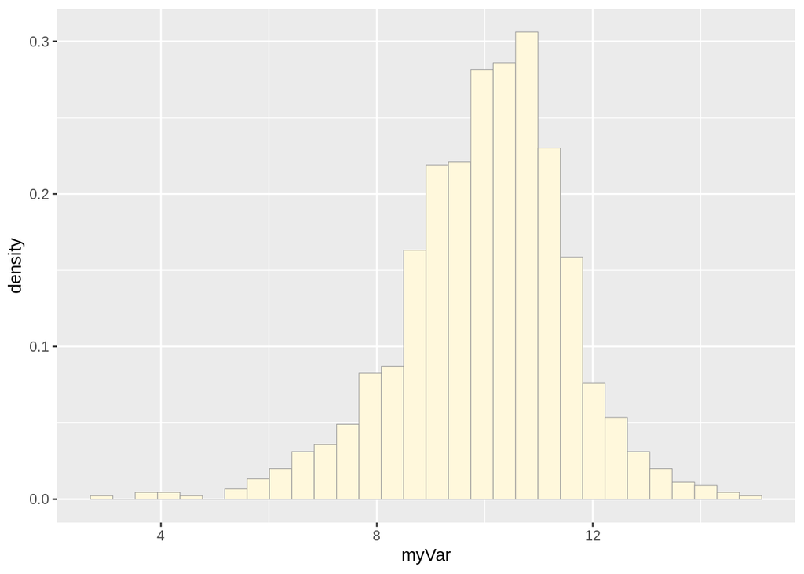

```r
p1 <- ggplot(data=z, aes(x=myVar, y=..density..)) +
  geom_histogram(color="grey60",fill="cornsilk",size=0.2)
print(p1)
```

### Add empirical density curve

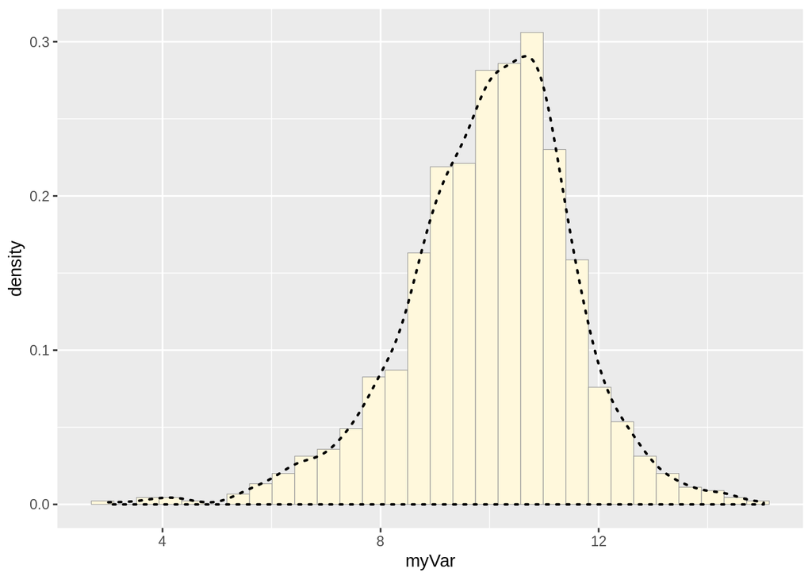

```r
p1 <-  p1 +  geom_density(linetype="dotted",size=0.75)
print(p1)
```

### Get maximum likelihood parameters for normal

```r
normPars <- fitdistr(z$myVar,"normal")
print(normPars)
```

```
##       mean           sd
##   10.00000102    1.53553436
##  ( 0.04672482) ( 0.03303944)
```

```r
str(normPars)
```

```
## List of 5
##  $ estimate: Named num [1:2] 10 1.54
##   ..- attr(*, "names")= chr [1:2] "mean" "sd"
##  $ sd      : Named num [1:2] 0.0467 0.033
##   ..- attr(*, "names")= chr [1:2] "mean" "sd"
##  $ vcov    : num [1:2, 1:2] 0.00218 0 0 0.00109
##   ..- attr(*, "dimnames")=List of 2
##   .. ..$ : chr [1:2] "mean" "sd"
##   .. ..$ : chr [1:2] "mean" "sd"
##  $ n       : int 1080
##  $ loglik  : num -1996
##  - attr(*, "class")= chr "fitdistr"
```

```r
normPars$estimate["mean"]
```

```
## mean
##   10
```

### Plot normal probability density

```r
meanML <- normPars$estimate["mean"]
sdML <- normPars$estimate["sd"]

xval <- seq(0,max(z$myVar),len=length(z$myVar))

 stat <- stat_function(aes(x = xval, y = ..y..), fun = dnorm, colour="red", n = length(z$myVar), args = list(mean = meanML, sd = sdML))
 p1 + stat
```

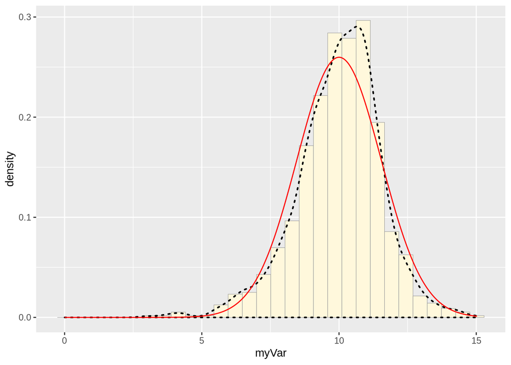

### Plot exponential probability density

```r
expoPars <- fitdistr(z$myVar,"exponential")
rateML <- expoPars$estimate["rate"]

stat2 <- stat_function(aes(x = xval, y = ..y..), fun = dexp, colour="blue", n = length(z$myVar), args = list(rate=rateML))
 p1 + stat + stat2
```

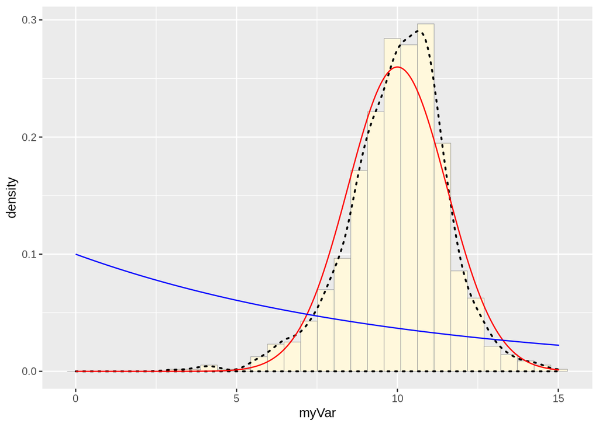

### Plot uniform probability density

```r
stat3 <- stat_function(aes(x = xval, y = ..y..), fun = dunif, colour="darkgreen", n = length(z$myVar), args = list(min=min(z$myVar), max=max(z$myVar)))
 p1 + stat + stat2 + stat3
```

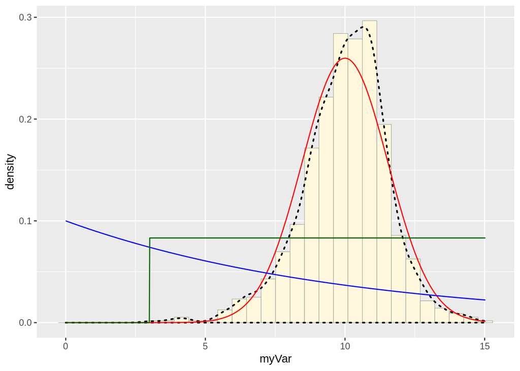

### Plot gamma probability density

```r
gammaPars <- fitdistr(z$myVar,"gamma")
shapeML <- gammaPars$estimate["shape"]
rateML <- gammaPars$estimate["rate"]

stat4 <- stat_function(aes(x = xval, y = ..y..), fun = dgamma, colour="green", n = length(z$myVar), args = list(shape=shapeML, rate=rateML))
 p1 + stat + stat2 + stat3 + stat4
```

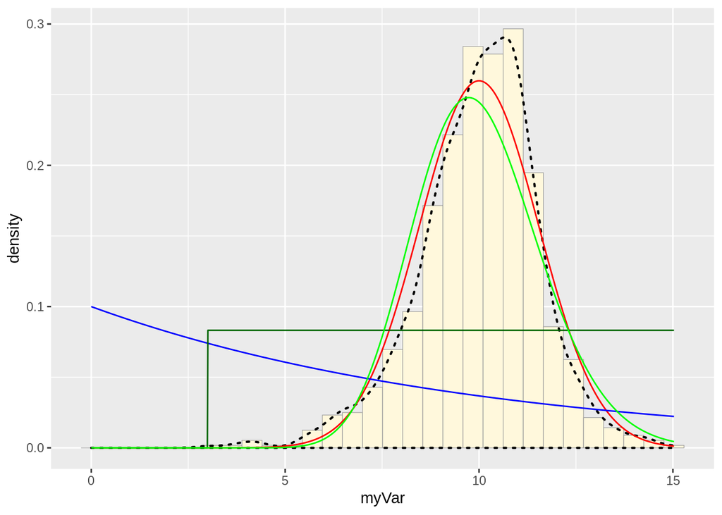

### Plot beta probability density

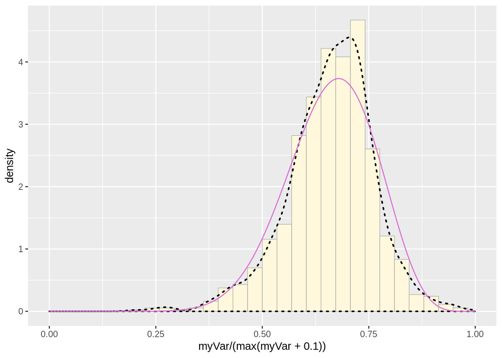

```r
pSpecial <- ggplot(data=z, aes(x=myVar/(max(myVar + 0.1)), y=..density..)) +
  geom_histogram(color="grey60",fill="cornsilk",size=0.2) +
  xlim(c(0,1)) +
  geom_density(size=0.75,linetype="dotted")

betaPars <- fitdistr(x=z$myVar/max(z$myVar + 0.1),start=list(shape1=1,shape2=2),"beta")
shape1ML <- betaPars$estimate["shape1"]
shape2ML <- betaPars$estimate["shape2"]

statSpecial <- stat_function(aes(x = xval, y = ..y..), fun = dbeta, colour="orchid", n = length(z$myVar), args = list(shape1=shape1ML,shape2=shape2ML))
pSpecial + statSpecial
```

## Simulating a Distribution

From the above section, I’d say the normal distribution fits this data set best, so I’ll be sampling from a normal distribution for simulating new data.

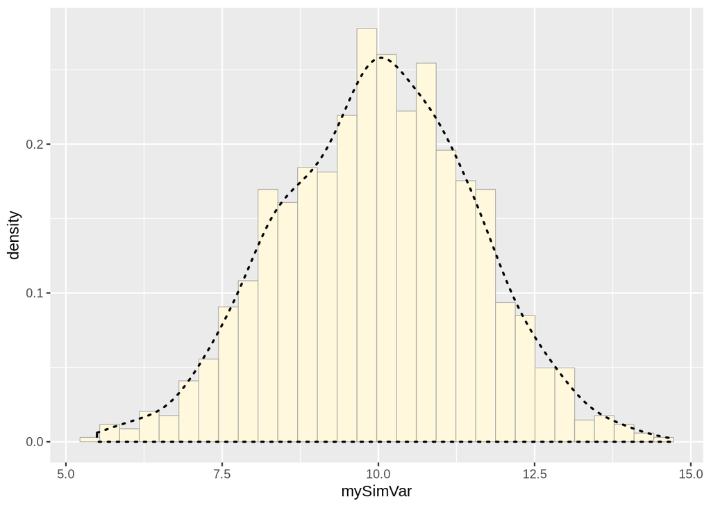

```r
simData = rnorm(n=length(z$myVar), mean=meanML, sd=sdML)
simData = data.frame(1:length(z$myVar), simData)
names(simData) = c("ID", "mySimVar")
p1 <- ggplot(data=simData, aes(x=mySimVar, y=..density..)) +
  geom_histogram(color="grey60",fill="cornsilk",size=0.2)
p1 +  geom_density(linetype="dotted",size=0.75)
```

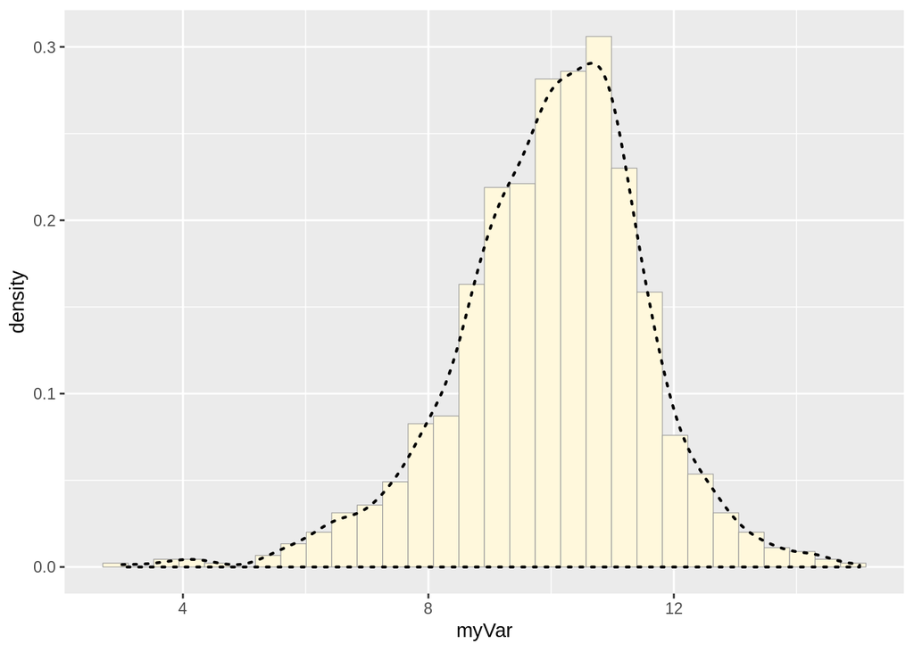

```r
p2 <- ggplot(data=z, aes(x=myVar, y=..density..)) +
  geom_histogram(color="grey60",fill="cornsilk",size=0.2)
p2 +  geom_density(linetype="dotted",size=0.75)
```

### How do the two histogram profiles compare?

It seems that the simulated data is a good bit more spread. I’d say that the “bump” of outliers seen on the lower end of the histogram in the real data caused the maximum-likelyhood standard deviation to be larger than if the data did not have this bump. Then, by simulating the data with this distribution, the information about these outliers is lost and instead we end up with data that seems too far spread about the mean.

Using a gamma distribution is also quite sensitive to these lower outliers, though the result looks quite different:

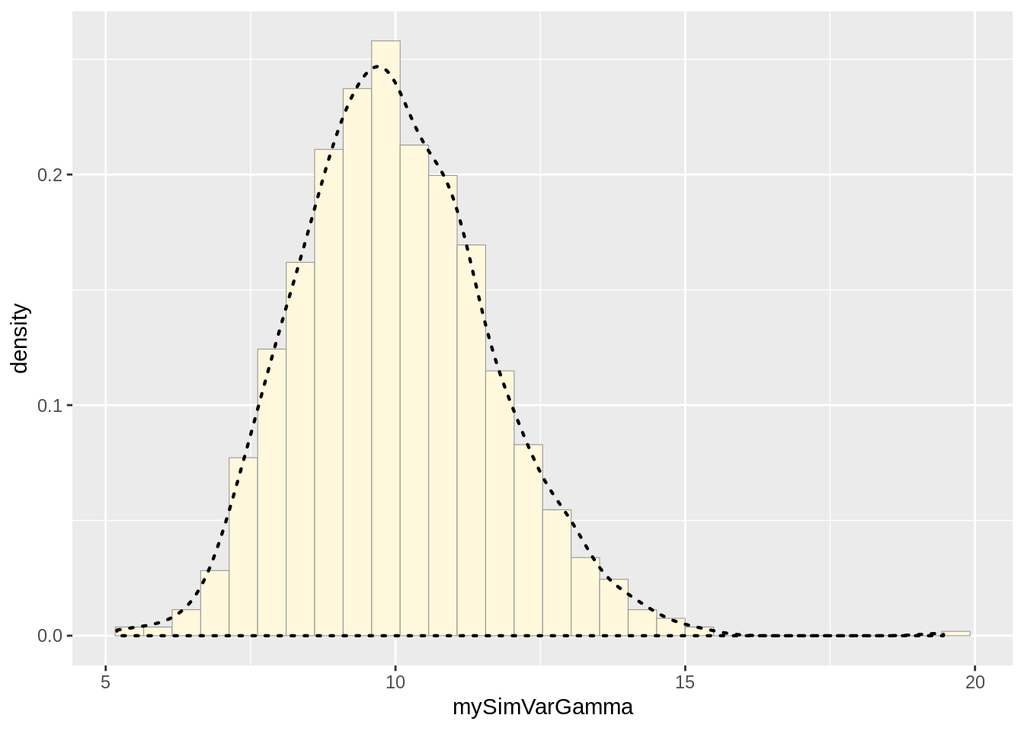

```r
simData = rgamma(n=length(z$myVar), shape=shapeML, rate=rateML)
simData = data.frame(1:length(z$myVar), simData)
names(simData) = c("ID", "mySimVarGamma")
p1 <- ggplot(data=simData, aes(x=mySimVarGamma, y=..density..)) +
  geom_histogram(color="grey60",fill="cornsilk",size=0.2)
p1 +  geom_density(linetype="dotted",size=0.75)
```